# Discrete Laplacian

This section is based on [Keenan Crane - Discrete Differential Geometry](https://www.cs.cmu.edu/~kmcrane/Projects/DDG/).

Let $M$ be closed compact and oriented surface in $\mathbb{R}^3$. Let $K$ be a triangulation of $M$, such that every angle is acute; and enumerate the vertex set of $K$ with $\lbrace 0, \ldots, \lvert{K}\rvert\rbrace$.

The Laplace-Beltrami (from now on, just the laplacian) $\Delta$ is given as $$ \Delta u = \nabla \cdot (\nabla u) $$ where $\nabla\cdot$ and $\nabla$ are the divergence and gradient operator, respectively.

## A formulation of $\Delta$ using FEM

Finite Element Analysis is the backend of Finite Element Methods; the former being a *methodology* for solving and analyzing PDEs consisting of discretizing the space of functions where the solution is seek. In this framework, it's assumed that a tesselation of the domain (in our case, a mesh) is given and in every geometrical primitive (for example, triangles) a finite dimensional space of functions is defined. For our purpose, we choose in each element linear polynomials. The choice of functions and its properties is what constitutes FEA.

The laplacian in FEA is usually considered to be an operator from $H^1$ to its dual $H^{-1}$. As such, the distribution $\Delta u$ acts on functions $v\in H^1$. Let $N_j$ be the hat function that gets the value of $1$ at node/vertex $j$ and $0$ on its neighbors. The action of the laplacian on every $N_j$ gives us the value of the laplacian at node $j$. Therefore, we are interested in the vector $$ \mathbf{U} = (\langle \Delta u, N_0 \rangle, \langle \Delta u, N_1 \rangle, \ldots, \langle \Delta u, N_{\lvert K\rvert} \rangle). $$ Using integration by parts and the divergence theorem in each element we get: $$ \begin{aligned} \langle \Delta u, N_j \rangle &= \sum_{T\colon j\in T} \langle \Delta u, N_j \rangle_{T} \\&= \sum_{T\colon j\in T} \langle \nabla u, \nabla N_j\rangle + \langle \mathbf{n} \cdot \nabla u, N_j\rangle_{\partial T}, \end{aligned} $$ where $\mathbf{n}$ is the outward normal of the triangle involve, and the sum runs for all triangles in the mesh. Notice that $$ \sum_{T\colon j\in T} \langle \mathbf{n} \cdot \nabla u, N_j\rangle_{\partial T} = \sum_{e\in\text{Edges}} \langle \mathbf{n}\cdot\nabla u, N_j\rangle_{e} - \langle \mathbf{n}\cdot\nabla u, N_j\rangle_{e} = 0. $$ All together, the action of the laplacian reads: $$ \langle \Delta u, N_j \rangle = \sum_{T\colon j\in T} \langle \nabla u, \nabla N_j\rangle_{T}. $$ And discretizing $u = \sum_{i=0}^{\lvert{K}\rvert} u_i N_i$ we get: $$ \langle \nabla u, \nabla N_j\rangle_{T} = \sum_{i=0}^{\lvert K \rvert} u_i \langle \nabla N_i, \nabla N_j\rangle_{T} = \sum_{i\in T} u_i \langle \nabla N_i, \nabla N_j \rangle_T. $$ Therefore, we end up with the following expression: $$ \langle \Delta u, N_j \rangle = \sum_{T\colon j\in T} \langle \nabla u, \nabla N_j\rangle_{T} = \sum_{T\colon j\in T} \sum_{i\in T} u_i \langle \nabla N_i, \nabla N_j\rangle_{T}. $$ This sum runs for all triangles and all vertex in those triangles. We can rearrange it by taking the sum over all neighbors $i$ of $j$ and compute the action for the two triangles adyacent to the edge $ij$; for the case $i=j$ we need to pass for every triangle containing $j$ and compute the action there. In all, we have the following expression. $$ \langle \Delta u, N_j \rangle = \sum_{i\in N(j)} u_i \left( \langle \nabla N_i, \nabla N_j\rangle_{T_i} + \langle \nabla N_i, \nabla N_j\rangle_{T_i'} \right) + \sum_{T\colon j\in T} u_j \langle \nabla N_j, \nabla N_j\rangle_{T}. $$ In summary, $$ \mathbf{U}_{j} = \sum_{i\in N(j)} \left( \langle \nabla N_i, \nabla N_j\rangle_{T_i} + \langle \nabla N_i, \nabla N_j\rangle_{T_i'} \right) + \sum_{T\colon j\in T} \langle \nabla N_j, \nabla N_j\rangle_{T}. $$

## Computing $\mathbf{U}$

In order to compute $\mathbf{U}$, we need to compute two kind of inner products:

1. $\langle \nabla N_i, \nabla N_j \rangle_{T}$ for $i\ne j$
2. $\langle \nabla N_i, \nabla N_i \rangle_{T}$.

Let's start by computing $\nabla N_i$, since we need it for all computations. Let $e$ be the edge opposite to $i$ in the triangle $T$. Since $N_i$ is linear, its gradient is a constant vector. Given that $N_i$ vanishes over $e$ and increases linearly until the value $1$ at node $i$, we may conclude that $$ \nabla N_i = - \frac{1}{h} \mathbf{n}_i, $$ where $\mathbf{n}_i$ is the outward unit normal to $T$ at $e$ and $h$ is the height of the triangle measured from $e$ to $i$. Let $b$ denote the length of $e$. Then, $|T| = \frac{1}{2} hb$. Solving for $h$ and substituting in the equation above yields: $$ \nabla N_i = -\frac{b}{2|T|} \mathbf{n}_i. $$

**1.** Let $i$ and $j$ be neighboring vertex. Then, $$ (\nabla N_i, \nabla N_j) = \frac{b_i b_j}{4 |T|^2} \int_{T} \mathbf{n}_i \cdot \mathbf{n}_j = - \frac{b_i b_i}{4 |T|} \cos(\theta_{ij}), $$ where $\theta_{ij}$ is the angle between $\mathbf{n}_i$ and $\mathbf{n}_j$. The minus sign is a consequence of the acute angle requirement (the reader is invited to draw). Given that $2|T| = b_i b_j\sin(\theta_{ij})$ the expression simplifies to: $$ \langle \nabla N_i, \nabla N_j \rangle_{T} = -\frac{1}{2} \cot(\theta_{ij}). $$

**2.** Let's compute it directly, with the same notation as above: $$ (\nabla N_i, \nabla N_i) = \frac{b^2}{4 |T|} |T| = \frac{b}{2 h} = \frac{1}{2} (\cot \alpha_i + \cot \alpha_j), $$ where the last inequality follows from $2|T| = bh$ and the identity $b/h = \cot\alpha_i + \cot\beta_i$. Here's a short proof of the identity: Split $T$ into two right triangles. Let $b_1$ and $b_2$ denote the diagonals associated to angles $\alpha_i$ and $\beta_i$, respectively. Then $$ \cot\alpha_i + \cot\beta_i = \frac{b_1 \cos\alpha_i}{h} + \frac{b_2\cos\beta_i}{h} = \frac{b}{h}. $$

Let $N(j)$ denote the neighbors of $j$. Now the expression for $\mathbf{U}$ reads $$ \begin{aligned} \mathbf{U}_{j} &= \sum_{i\in N(j)} u_i \left( \frac{1}{2} \cot(\theta_{ij}) + \frac{1}{2} \cot(\theta_{ij}') \right) - \sum_{T\colon j\in T} u_j \frac{1}{2} (\cot_j \alpha + \cot \beta_j) \\&= \frac{1}{2} \left( \sum_{i\in N(j)} u_i \left( \cot(\theta_{ij}) + \cot(\theta_{ij}')\right) - u_j \sum_{\theta \textrm{ opposite to } j} \cot\theta \right) \\&= \frac{1}{2} \left( \sum_{i\in N(j)} u_i \left( \cot(\theta_{ij}) + \cot(\theta_{ij}')\right) - u_j \sum_{i\in N(j)} \left( \cot(\theta_{ij}) + \cot(\theta_{ij}')\right) \right) \\&= \frac{1}{2} \sum_{i\in N(j)} \left( \cot(\theta_{ij}) + \cot(\theta_{ij}')\right) (u_i - u_j) \end{aligned} $$ where $\theta_{ij}$ and $\theta_{ij}'$ in each sum being the angle opposite to edge $ij$ in each triangle. This concludes the famous cotangent formula for the Laplace-Beltrami discretization.

## Matrix form

In order to perform computations effiently, we'll rewrite $\mathbf{U} = \mathbf{L}\vec{u}$, for a matrix $\mathbf{L}$. So that $\mathbf{L} \approx \Delta$.

From the equation defining $\mathbf{U}$ we get that $$ 2 \mathbf{L}_{ij} = \begin{cases} \cot(\theta_{ij}) + \cot(\theta_{ij}') &, \textrm{ if } i\ne j\\ -\sum_{k=0, k\ne j}^{\lvert{K}\rvert} L_{ik} &, \textrm{ if } i=j \end{cases}. $$

### Extra: Computing $\cot$

Let $x$ and $y$ be the vectors whose angle is $\theta$. Then, $\frac{x\cdot y}{\|x\times y\|} = \cot(\theta)$.

```python
from scipy.sparse import lil_matrix
import numpy as np

def laplace_matrix(nodes: list, triangles: list) -> (lil_matrix, lil_matrix):
    '''
    Input:
        - nodes : [#nodes]x[3]. nodes[i] contains the cartesian coordinates of the ith node.
        - triangles :[#triangles]x[3]. triangles[i] contains the indexes of the vertices of the ith triangle.
    Output:
        - the cotan-Laplace matrix in lil_matrix format.
        - the mass matrix
    '''
    N = len(nodes)
    L = lil_matrix((N,N), dtype=np.float32)
    M = lil_matrix((N,N), dtype=np.float32)

    # Fill non diagonals
    for T in triangles:
        # Fill cotan matrix
        i, j, k = T
        x, y, z = nodes[T]

        # Relative vectors
        ie1 = y-x; ie2 = z-x
        je1 = z-y; je2 = x-y
        ke1 = x-z; ke2 = y-z

        # Mass matrix
        area = np.linalg.norm(np.cross(ie1, ie2))
        M[i,i] += area
        M[k,k] += area
        M[j,j] += area

        # Compute cotangents
        cot_i = abs(np.dot(ie1, ie2)) / np.linalg.norm(np.cross(ie1, ie2))
        cot_j = abs(np.dot(je1, je2)) / np.linalg.norm(np.cross(je1, je2))
        cot_k = abs(np.dot(ke1, ke2)) / np.linalg.norm(np.cross(ke1, ke2))

        L[i,j] += cot_k; L[j,i] += cot_k
        L[i,k] += cot_j; L[k,i] += cot_j
        L[j,k] += cot_i; L[k,j] += cot_i

    # Fill diagonals
    for i in range(N):
        L[i, i] = -sum([L[i,j] for j in range(N)])

    return L/2, M/6
```

# Example

```python
import pyvista as pv
pv.set_jupyter_backend('static')

import numpy as np
from scipy.sparse import lil_matrix, identity
import scipy.sparse.linalg as spla

import matplotlib.pyplot as plt
```

```
Decimated mesh, from  112402 faces to 20000 faces
# Nodes  : (10002, 3)
# Faces  : (20000, 3)
```

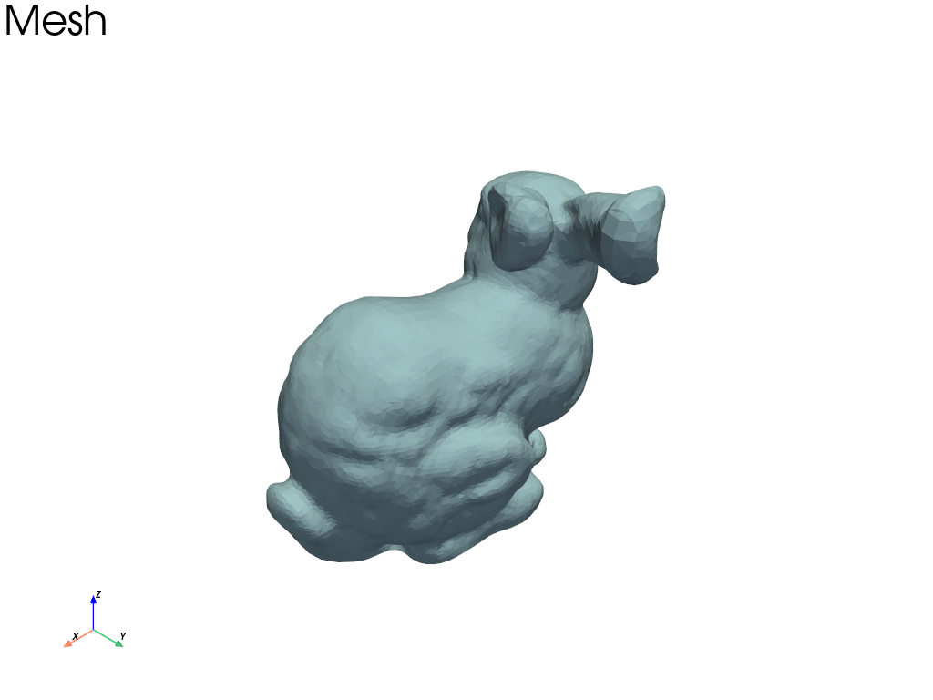

```python
MAX_FACES = 20_000

mesh = pv.PolyData('3D_models/Stanford_Bunny.stl')

num_faces = len(mesh.faces) // 4

if num_faces > MAX_FACES:
    mesh = mesh.decimate(1.0 - (MAX_FACES / num_faces))
    print('Decimated mesh, from ', num_faces, 'faces to', len(mesh.faces)//4, 'faces')

nodes = mesh.points
triangles = np.delete(mesh.faces.reshape(-1, 4), 0, 1)

print('# Nodes  :', nodes.shape)
print('# Faces  :', triangles.shape)

mesh.plot(text='Mesh')
```

```python
L, M = laplace_matrix(nodes, triangles)
```

[figure not shown]

```python
from random import sample

default_cmap = plt.get_cmap('seismic')

source_indices = [1591, 9587]
source_field = np.zeros(len(nodes))
source_field[source_indices] = [(-1)**i/len(source_indices) for i in range(len(source_indices))]

vmax = np.max(source_field)
vmin = np.min(source_field)

mesh.plot(scalars=source_field, clim=[vmin, vmax], cmap=default_cmap, text='Heat Source')
```

```python
steady_heat = -spla.spsolve(L.tocsr(), source_field)
```

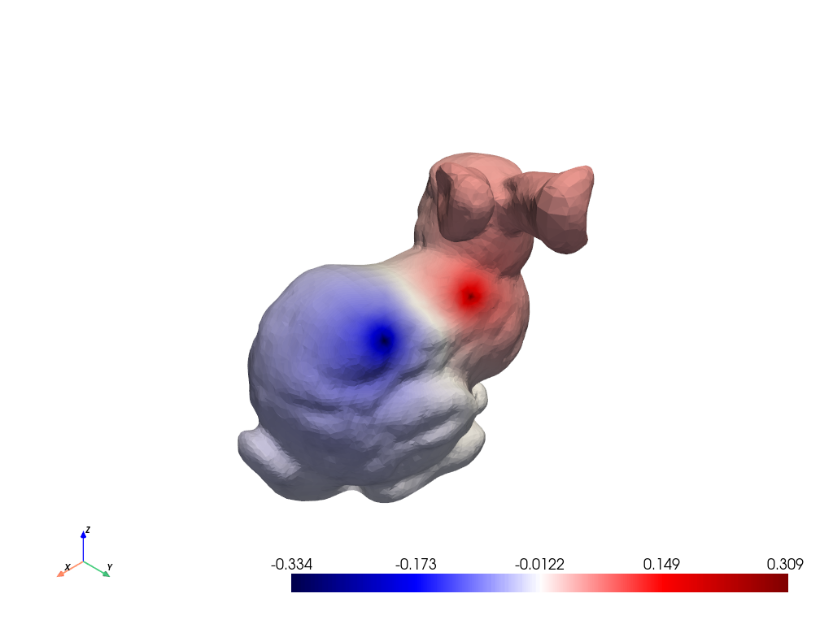

```python
mesh.plot(scalars=steady_heat, cmap=default_cmap, show_scalar_bar=True)
```